# Data 624 - Homework 2

The data below represent the monthly sales (in thousands) of product A for a plastics manufacturer for years 1 through 5 (data set plastics).

```r
library(fma)
plastics
```

```
##    Jan  Feb  Mar  Apr  May  Jun  Jul  Aug  Sep  Oct  Nov  Dec
## 1  742  697  776  898 1030 1107 1165 1216 1208 1131  971  783
## 2  741  700  774  932 1099 1223 1290 1349 1341 1296 1066  901
## 3  896  793  885 1055 1204 1326 1303 1436 1473 1453 1170 1023
## 4  951  861  938 1109 1274 1422 1486 1555 1604 1600 1403 1209
## 5 1030 1032 1126 1285 1468 1637 1611 1608 1528 1420 1119 1013
```

1. Plot the time series of sales of product A. Can you identify seasonal fluctuations and/or a trend?

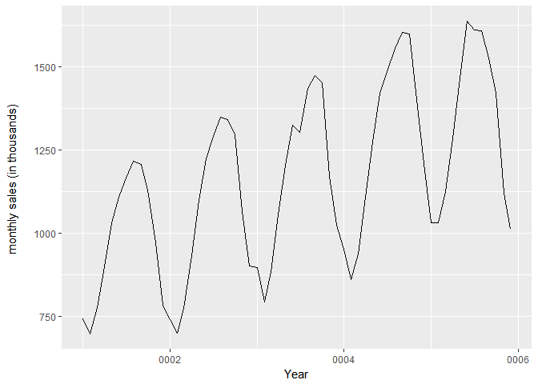

```r
library(ggfortify)
autoplot(plastics, xlab = "Year", ylab = "monthly sales (in thousands) \n")
```

> There is clearly seasonal fluctuations here, it shows a trend towards high volume in summer and a sharp dip in winter for lower volume.
2. Use a classical multiplicative decomposition to calculate the trend-cycle and seasonal indices.

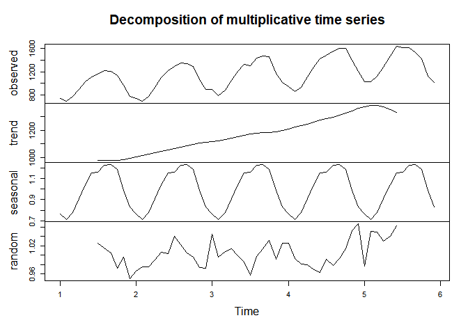

```r
fit <- decompose(plastics, type="multiplicative")
plot(fit)
```

3. Do the results support the graphical interpretation from part (a)?

> The results do support the seasonality trend assumption from part (a), it is useful to see the seasonal trend accounting for upward trend in the observed values to highlight the consistent seasonality.
4. Compute and plot the seasonally adjusted data.

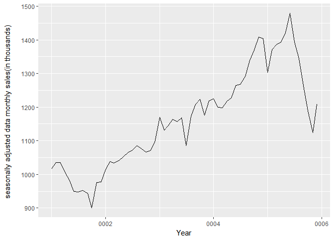

```r
fit <- stl(plastics, t.window = 7, s.window="periodic", robust=TRUE)
autoplot(seasadj(fit), xlab = "Year", ylab = "seasonally adjusted data monthly sales(in thousands) \n")
```

5. Change one observation to be an outlier (e.g., add 500 to one observation), and recompute the seasonally adjusted data. What is the effect of the outlier?

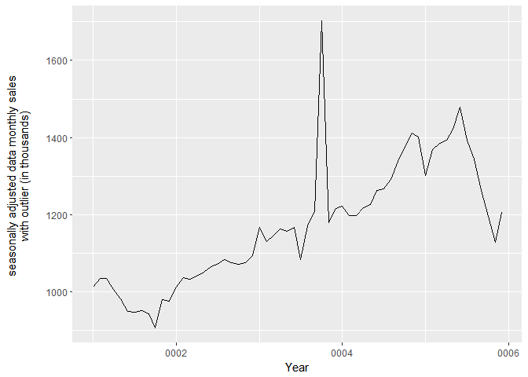

```r
outlier_plastics <- plastics
outlier_plastics[34] <- outlier_plastics[30] + 600
fit <- stl(outlier_plastics, t.window = 7, s.window="periodic", robust=TRUE)
autoplot(seasadj(fit), xlab = "Year", ylab = "seasonally adjusted data monthly sales \n with outlier (in thousands)  \n")
```

> Surpisingly, the effect of an outlier has very little impact on the overall trend of the line but does show considerable impact on the line at the point of the outlier.
6. Does it make any difference if the outlier is near the end rather than in the middle of the time series?

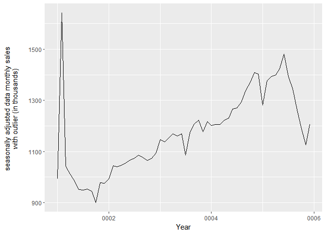

```r
outlier_plastics <- plastics
outlier_plastics[2] <- outlier_plastics[2] + 600
fit <- stl(outlier_plastics, t.window = 7, s.window="periodic", robust=TRUE)
autoplot(seasadj(fit), xlab = "Year", ylab = "seasonally adjusted data monthly sales \n with outlier (in thousands)  \n")
```

> It does appear that there is an initial smoothing of the line from the outlier at the beginning of the series. The line does return to a similar seasonally adjusted line from the original data which makes sense once the line is further out from the outlier. It does seem intiuitive that with an outlier at the beginning of the time series there is less surrounding data to account for the outlier.
7. Use a random walk with drift to produce forecasts of the seasonally adjusted data.

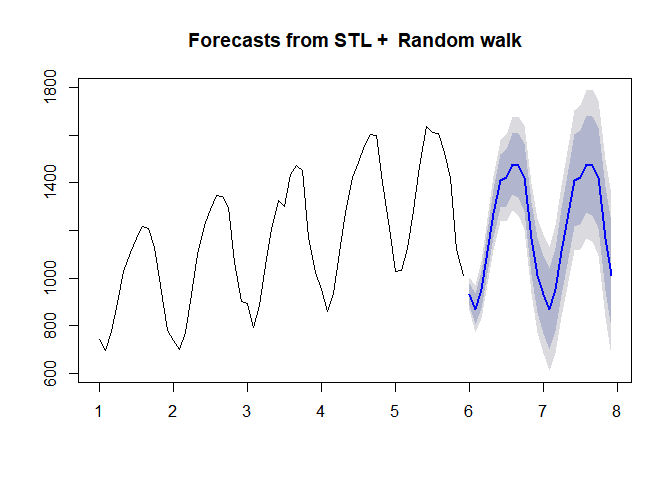

```r
fc <- stlf(plastics, method="naive")
plot(fc)
```

8. Reseasonalize the results to give forecasts on the original scale.

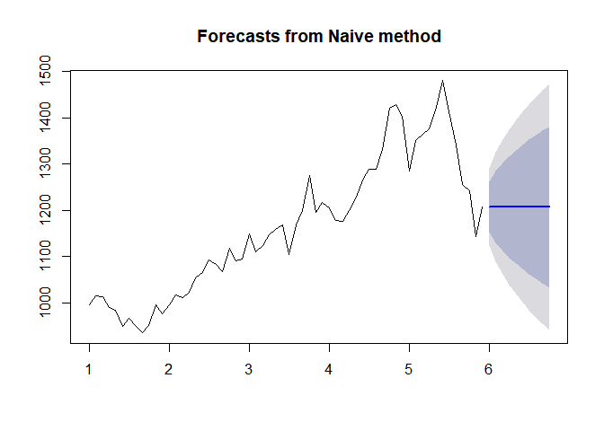

```r
fit <- stl(plastics, s.window="periodic", robust=TRUE)
fitadj <- seasadj(fit)
plot(naive(fitadj))
```